# Lecture 5: Averages

author: CPECGM2 font-family: Helvetica autosize: false width:1440 height:900

# R: the `list` variable type

In R, every function returns exactly one object.

To get around this limitation, often a function will return one object which is a `list` of different objects.

```r
# what is the probability of 371 heads in 500 coin flips?
test.result = binom.test(x = 261, n = 500, p = 0.5)
# what are the objects in the list?
names(test.result)
```

```
## [1] "statistic"   "parameter"   "p.value"     "conf.int"    "estimate"
## [6] "null.value"  "alternative" "method"      "data.name"
```

```r
# use the $ notation to extract an object
test.result$p.value
```

```
## [1] 0.3476642
```

# Agenda

- Review: hypothesis tests and p-values for binomial random varaibles
- Visualizing averages and sample sizes: US county statistics

**Important:** Read “percentages.pdf” first!

Main idea: When comparing averages, you should consider the **sample size**

We’ll use the following packages

```r
library(ggplot2)
library(plyr)
library(reshape2)
library(knitr)
```

# Binomial Random Variables

In many settings, such as:

- how many deaths from cancer in different counties
- how many arrests in different counties
- how many successful sales in different months
- etc,

We are interested in identifying abnormal or unusual occurences

Simplest way to account for sample variance: model as a **binomial random variable**

# The Binomial Random Variable

A **Binomial(n,p)** random variable is:

The number of successes in **n** independent trials, if each trial has a **p** percent chance of succeeding.

> Parameters: **n**, **p**

> Expected value: **np**

> Standard deviation: **sqrt(np(1-p))**

**idea:** **n** tosses of a biased coin, which comes up heads with probability **p**.

# p-values

**null hypothesis:** Suppose normally, 1 out of every 2 customers leave without buying anything.

Today, **261** out of **500** customers did so.

Is this business as usual, or is something different going on?

```r
# do a binomial test: how likely is it to get >= 261/500 heads if the coin is 50/50?
test.result = binom.test(x=261, n = 500, p = 0.5)
# extract the p.value from the output
test.result$p.value
```

```
## [1] 0.3476642
```

This isn’t so unusual for a **Binomial(n=500, p=0.5)** random variable.

==========

What if **371** of **500** customers did so?

This would be **very unusual** for a **Binomial(n=500, p=0.5)** random variable. We can infer that **p** is greater than 0.5.

```r
binom.test(x = 371, n = 500, p = 0.5, alternative = 'greater')$p.value
```

```
## [1] 1.819731e-28
```

So, not business as usual.

Difference could be benign (weekend/weekday effects), or serious (new competitor? worse customer service?)

# Rule of thumb for p-values

For many random variables, the probabilities approximately follow:

| st. deviations above the mean | approximate p-value |
| --- | --- |
| more than 1 sd | 30% |
| more than 2 sd | 5% |
| more than 3 sd | less than 1% |

**Example:** A binomial(n=500, p=.5) random variable has

Expectation: **250**  
Std. deviation: **11.2**

So **371** would be **10.8 standard deviations** above the mean. Very unlikely to occur.

# Terminology

**residual**: difference between actual data and your null hypothesis

**standardized residual**: normalize by the standard deviation given by the null hypothesis

Residual: 371-250 = 121  
Standardized residual: 121 / 11.2 = 10.8 std.devs

Residuals are very important in this course. They show where your model or hypothesis could be wrong.

# Silly Example

Suppose a magician has 4 coins. Three of them are fair, but the other is a trick coin, biased towards heads. You get to toss each one a number of times and record the outcomes

| coin | number of tosses | number of heads | percent |
| --- | --- | --- | --- |
| A | 3 | 2 | 66% |
| B | 10 | 7 | 70% |
| C | 50 | 32 | 64% |
| D | 90 | 50 | 55% |

The magician asks to you pick the coin whose **p** is greater than 1/2. But if you guess wrong, he’ll make you disappear!

For which coin is the evidence most in favor of **p** > 0.5?

# Silly Example

| coin | number of tosses | number of heads | percent | p-val that **p less than 0.5** |
| --- | --- | --- | --- | --- |
| A | 3 | 2 | 66% | 0.50 |
| B | 10 | 7 | 70% | 0.17 |
| C | 50 | 32 | 64% | 0.03 |
| D | 90 | 50 | 55% | 0.17 |

It would be pretty unlikely to get 32 heads in 50 tries if **p** was 1/2 or less.

Trick question: if you pick **C**, what is your chance of disappearing?

# Silly Example

| coin | number of tosses | number of heads | percent | p-val that **p less than 0.5** |
| --- | --- | --- | --- | --- |
| A | 3 | 2 | 66% | 0.50 |
| B | 10 | 7 | 70% | 0.17 |
| C | 50 | 32 | 64% | 0.03 |
| D | 90 | 50 | 55% | 0.17 |

It would be pretty unlikely to get 32 heads in 50 tries if **p** was 1/2 or less.

Trick question: if you pick **C**, what is your chance of disappearing?

Not enough information to answer.

# Real Example: US counties in 2007

`county_data.csv` has the following columns

- `name`: the county name
- `STCOU`: county code. Matches the column `fips` in the data frame `county.gg`.
- `population`, `violent.crimes`, `births`, `deaths`, `infant.deaths`: the number of each respective category in each county, in the year 2007.

```r
# load the CSV file
county.data <- read.csv(file = 'county_data.csv')
load('county_ggplot.rda')
```

===========

Let’s convert some of the columns to per capita rates:

```r
# compute per capita rates for each column
county.data = mutate(county.data,
        crimes.per.capita = violent.crimes / population,
        births.per.capita = births / population,
        deaths.per.capita = deaths / population,
        infant.deaths.per.capita = infant.deaths / population)
```

To make choropleth plots, we will need to `merge()` the `county.gg` and `county.data` into a single data frame:

```r
# combine the county.data with the map data
county.mapdata = merge(county.gg, county.data, by.x = 'fips', by.y='STCOU')
# merge can change the order of the rows. make sure they are in the correct order:
county.mapdata = arrange(county.mapdata, order)
```

# Deaths in US counties

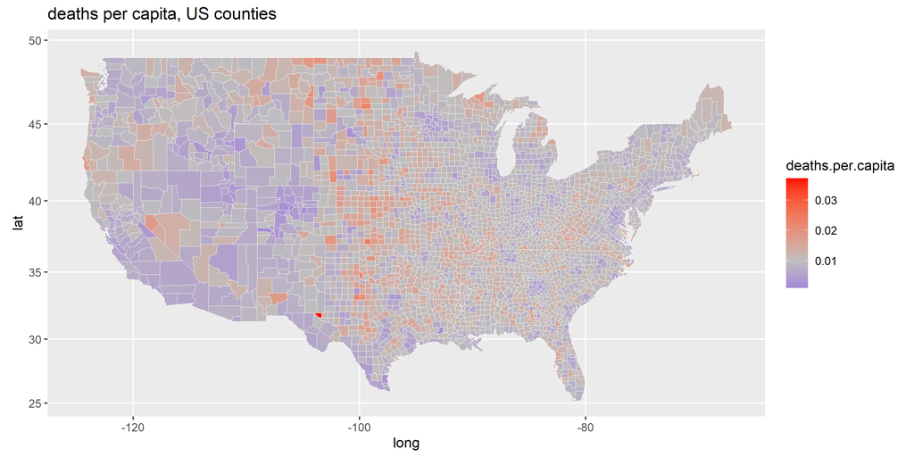

There are patches of counties with high death rates, such as a vertical band of midwest counties. What is going on here?

========

It turns out these counties also have small populations:

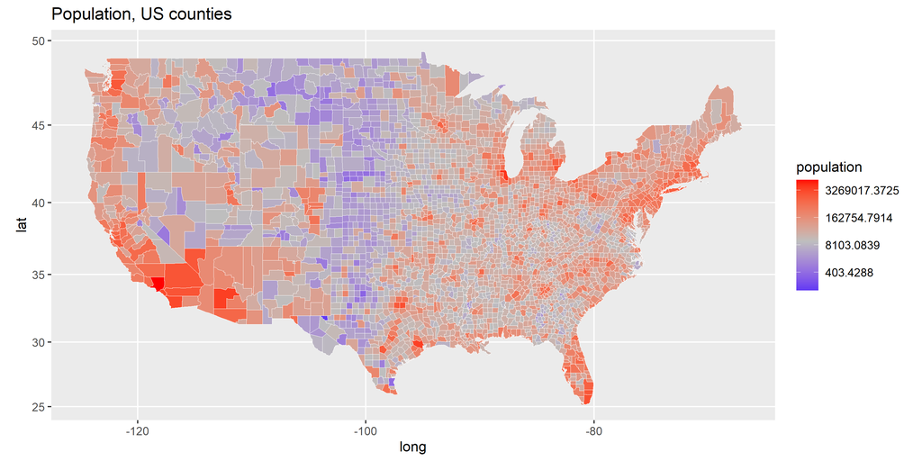

We can see that the midwest counties with high death rates also tended to have low populations.

=======

Here is a list of the counties with the top ten death rates:

| name | population | deaths | deaths.per.capita |
| --- | --- | --- | --- |
| Loving, TX | 54 | 2 | 0.037 |
| Comanche, KS | 1836 | 44 | 0.024 |
| McIntosh, ND | 2723 | 62 | 0.023 |
| Stonewall, TX | 1376 | 31 | 0.023 |
| Harmon, OK | 2833 | 62 | 0.022 |
| Wibaux, MT | 903 | 19 | 0.021 |
| Garden, NE | 1843 | 38 | 0.021 |
| Haskell, TX | 5147 | 106 | 0.021 |
| Nelson, ND | 3224 | 65 | 0.020 |
| Garfield, NE | 1724 | 34 | 0.020 |

They all have low populations. Some of them may have just had bad years…

# Let’s make the question well-posed

**Setup:**

Let’s suppose that the number of deaths in each county is a **binomial random variable**, with **n = population** and some intrinsic risk of death **p**.

**Question:**

For which counties is the evidence strongest that their **p** is above 0.008, the US per capita death rate?

# Computing the expected deaths and residuals

Instead of computing the exact p-value, let’s use the standardized residuals as a proxy:

```r
# compute the nationwide per capita rate:
US.deaths = sum(county.data$deaths) / sum(county.data$population)
# compute the expected and residual values under the null hypothesis:
county.augmented = mutate(county.data,
    expected.deaths = population * US.deaths,
    st.dev.deaths = sqrt(expected.deaths*(1 - US.deaths)),
    residual = deaths - expected.deaths,
    std.residual = residual / st.dev.deaths)
```

# Which counties had the largest std. residuals?

The top ten largest standardized residuals:

| name | population | deaths | deaths.per.capita | std.residual |
| --- | --- | --- | --- | --- |
| Pinellas, FL | 912764 | 10977 | 0.012 | 42.639 |
| Allegheny, PA | 1219922 | 13934 | 0.011 | 41.823 |
| Ocean, NJ | 565525 | 6840 | 0.012 | 34.142 |
| Sarasota, FL | 368841 | 4801 | 0.013 | 33.839 |
| Cuyahoga, OH | 1293600 | 13807 | 0.011 | 33.532 |
| Citrus, FL | 139838 | 2217 | 0.016 | 32.718 |
| Palm Beach, FL | 1264648 | 13442 | 0.011 | 32.597 |
| Luzerne, PA | 311934 | 4117 | 0.013 | 32.257 |
| Pasco, FL | 459566 | 5527 | 0.012 | 30.258 |
| Volusia, FL | 498769 | 5739 | 0.012 | 27.409 |

A lot of them are in Florida, which happens to be a popular destination among retirees who tend to be older.

=========

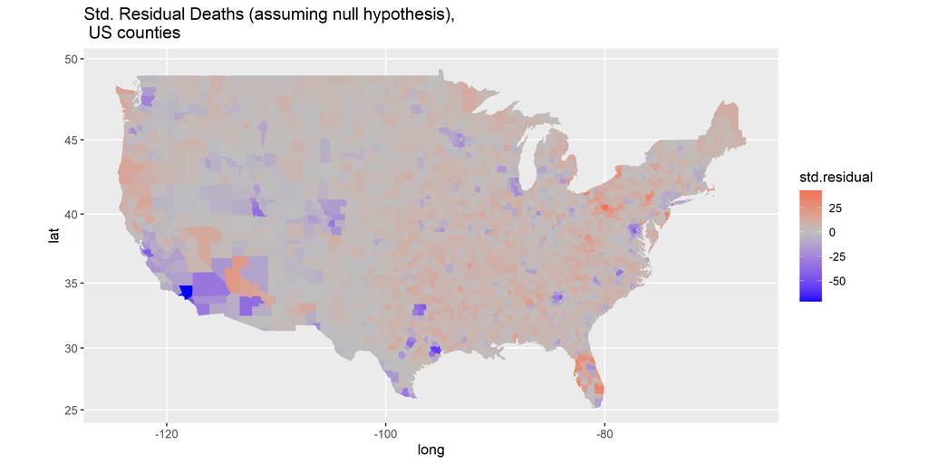

- Florida has a lot of red. Strong evidence that their **p** exceeds 0.008
- Some major cities are blue. Perhaps these cities are attracting large numbers of younger people?

# Small counties have higher variance

The per capita rate varies more for small counties:

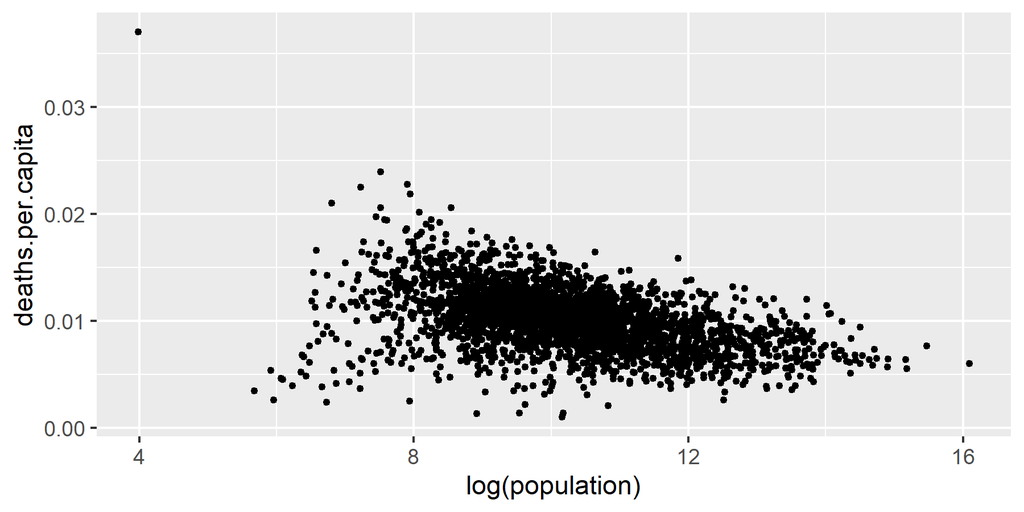

Note that we took a log transform of the `x` axis because some of the counties have very large populations. (try it without the log first!)

# Could all counties have the same intrinsic p?

If every county had the national rate, < 1 percent of counties should be more than 3 st.dev from the mean:

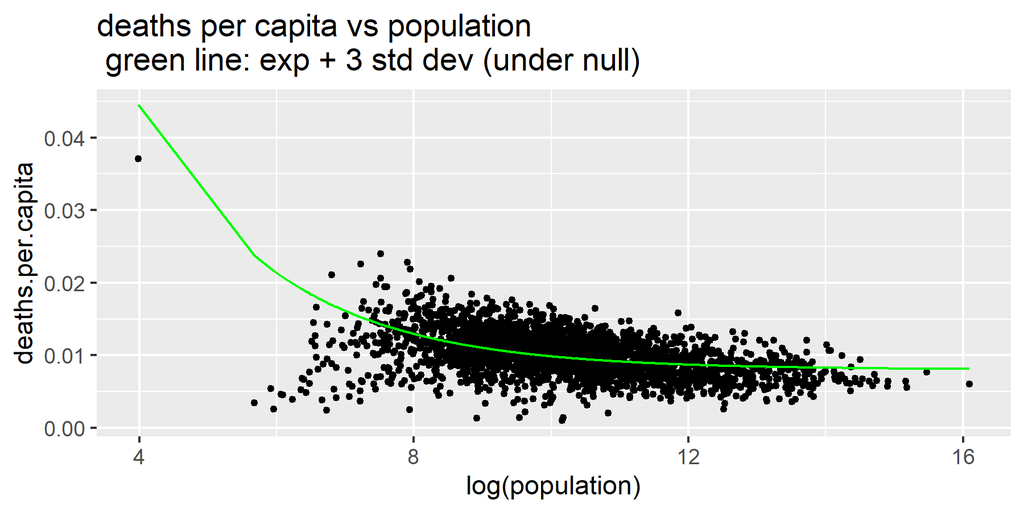

The number of counties above the green line is much more than 1 percent. Reject the null.

There are county-specific factors affecting the death rate!

# Infant deaths in US counties

The highest observed per capita rates are all small counties

| name | population | infant.deaths | infant.deaths.per.capita |
| --- | --- | --- | --- |
| Kenedy, TX | 387 | 1 | 0.003 |
| Blaine, NE | 442 | 1 | 0.002 |
| Roberts, TX | 843 | 1 | 0.001 |
| Garfield, NE | 1724 | 2 | 0.001 |
| Lane, KS | 1738 | 2 | 0.001 |
| Quitman, GA | 2649 | 3 | 0.001 |
| Terrell, TX | 917 | 1 | 0.001 |
| Crockett, TX | 3782 | 4 | 0.001 |
| Jones, SD | 1040 | 1 | 0.001 |
| Tunica, MS | 10491 | 9 | 0.001 |

Should this be taken as evidence that these counties have higher risks of infant mortality?

# Look at standardized residuals instead

Suppose the number of infant deaths for each county is a binomial random variable.

For which counties is the evidence strongest that their intrinsic **p** is greater than 0.0001, the US average?

```r
# how many infant deaths per capita in the US?
US.infant.deaths = sum(county.data$infant.deaths) / sum(county.data$population)

# compute the expected and residual counts under a simple null hypothesis
county.augmented = mutate(county.data,
    expected.infant.deaths = population * US.infant.deaths,
    st.dev.deaths = sqrt(expected.infant.deaths*(1-US.infant.deaths)),
    residual = infant.deaths - expected.infant.deaths,
    std.residual = residual / st.dev.deaths)
```

======

Top ten counties in terms of the standardized resisdual

| name | population | infant.deaths | infant.deaths.per.capita | std.residual |
| --- | --- | --- | --- | --- |
| Philadelphia, PA | 1530031 | 290 | 0.00019 | 11.75544 |
| Shelby, TN | 919964 | 193 | 0.00021 | 11.09504 |
| Norfolk, VA | 236051 | 68 | 0.00029 | 9.49630 |
| Tunica, MS | 10491 | 9 | 0.00086 | 7.94997 |
| District of Columbia | 586409 | 116 | 0.00020 | 7.92347 |
| Prince George’s, MD | 832699 | 149 | 0.00018 | 7.68625 |
| Hinds, MS | 248959 | 60 | 0.00024 | 7.35895 |
| Jefferson, AL | 661477 | 121 | 0.00018 | 7.18113 |
| Muscogee, GA | 186613 | 48 | 0.00026 | 7.08502 |
| Baltimore city, MD | 640150 | 115 | 0.00018 | 6.79708 |

=====

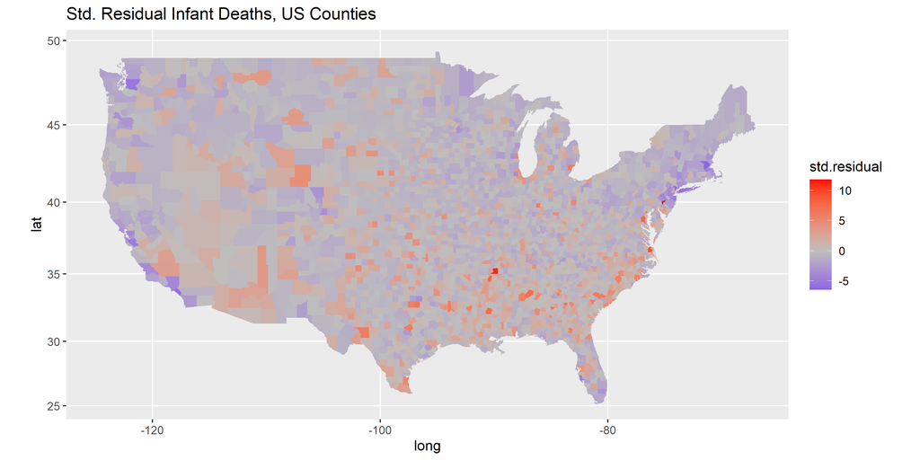

Regional trends seem to be visible

# Could all counties have the same intrinsic p?

If every county had the national rate, <1 percent of counties should be more than 3 st. dev. from the mean:

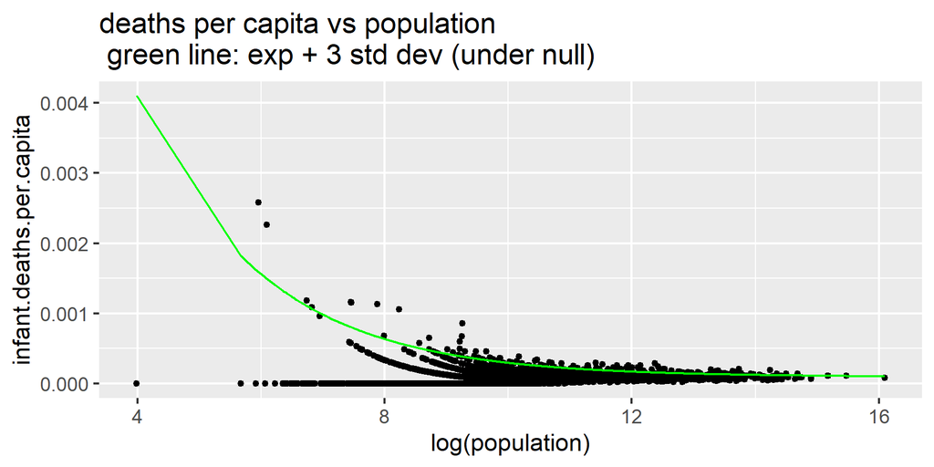

About 3.7% of the population. We can reject the null – there is some county-specific factor causing more infant deaths per capita.

However, much closer to the null than the previous example!

# Discussion

1. If you are looking for the most extreme values, **don’t compare per capita rates or averages**. This will just give you the smallest groups.
2. The simplest null hypothesis: all counties have the same risk factor
3. If this null is correct, less than 1% of counties should have a standardized residual above 3.
4. If not, there is some additional factor affecting the outcomes.
5. Choose a risk factor as the null and look for counties which reject it. Alternately, you can use confidence intervals (next lecture!)

# Discussion, cont:

Outliers and extreme values can mean different things in your analysis:

1. The outliers were so large and numerous that the null hypothesis was clearly wrong.

Look at the outliers and try to learn what makes them different from other counties.

2. They occur about as often as you might expect under the null.

In this case, they might just be due to random chance.

# Bonus: A common fix that doesn’t really work

What if we only look at counties with at least 10K people?

| name | population | deaths | deaths.per.capita |
| --- | --- | --- | --- |
| Sierra, NM | 12478 | 220 | 0.018 |
| Benton, TN | 16152 | 275 | 0.017 |
| Lancaster, VA | 11491 | 195 | 0.017 |
| Curry, OR | 21507 | 363 | 0.017 |
| Red River, TX | 13063 | 220 | 0.017 |
| Baxter, AR | 41845 | 689 | 0.016 |
| McDowell, WV | 22843 | 374 | 0.016 |
| Sabine, TX | 10147 | 166 | 0.016 |
| Trinity, TX | 14021 | 227 | 0.016 |
| Iron, MI | 11934 | 193 | 0.016 |

The highest rates are mostly counties with about 10K people now.

So the low population counties still have the highest rates.